# Report exercise 4.4

Elias Köppel

2023-03-13

Ozone (O3) is an air pollutant that is not directly emitted into the air, but instead it is formed through chemical reactions in the atmosphere when ultraviolet (UV) radiation from the sun interacts with nitrogen oxides (NOx = NO2 + NO) and volatile organic compounds (VOCs) (https://airquality.gsfc.nasa.gov/surface-level-ozone). Consequently, I expect that the ozone concentration increases with high temperatures. Given the fact that the ozone formation requires nitrogen oxides, which are released to the atmosphere through human actions (which mainly happen in the city), I expect that a high wind speed leads to an decrease of the ozone concentration because the air is being exchanged.

In the first step, I’m going to show three different graphs, which illustrate the relation between the two variables temperature and wind, and the ozone concentration in the air. Further, I’m going to discuss some statistical metrics.

In this first chunk, I’m just making the data ready for use:

```r
library(dplyr)
library(lubridate) #for converting the dates into month names
```

```r
#load pre-installed dataset "airquality"

data_airquality <- datasets::airquality



#add column with the date of the measurement to create a well comprehensible timeline in the following plots

data_airquality <- data_airquality |>
  mutate(date = seq(as.Date("1973/05/01"), as.Date("1973/09/30"), 1))








# extract the month names from the dates
data_airquality$month <- month(data_airquality$date, label = TRUE)
```

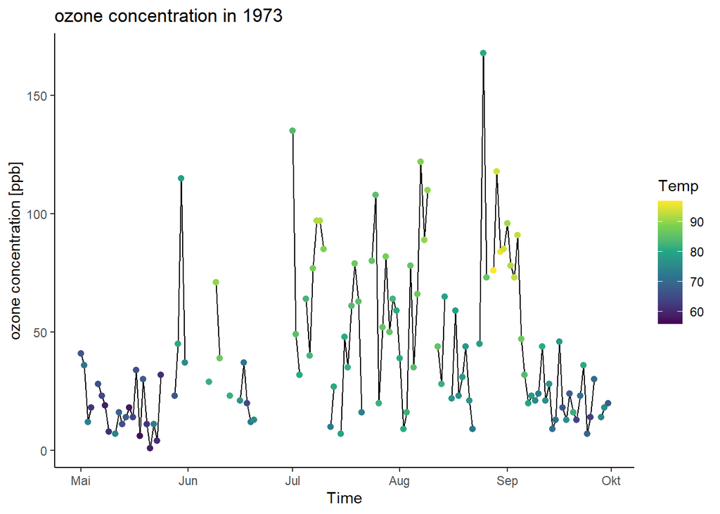

```r
library(ggplot2)

ggplot(
    data = data_airquality,
    aes(x = date, y = Ozone)) +
  geom_line() +
  geom_point(aes(color = Temp), size = 1.7) + ggtitle("ozone concentration in 1973") +
  labs(x = "Time",
       y = "ozone concentration [ppb]") +
  scale_color_viridis_c(direction = 1) + # inverse color scale is more intuitive here
  theme_classic()
```

This second graph shows ozone concentration and temperature and a very clear correlation between these two variables. Also, it includes linear regressions for the different months. What is interesting to see is that the slope of the straights of the two warmest months July and August are the steepest. So it seems as if the relation between ozone concentration and temperature is non-linear.

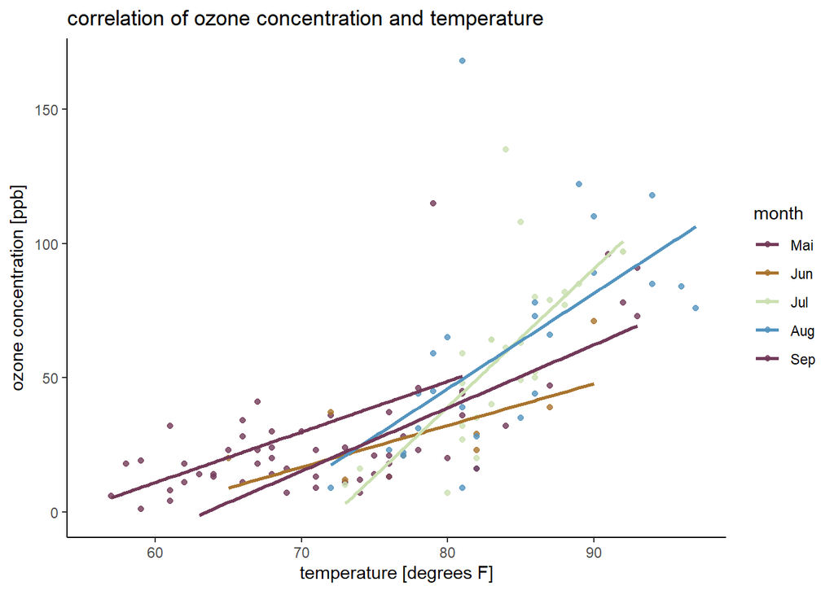

```r
library(dplyr)





ggplot(
  data = data_airquality,
  aes(x = Temp, y = Ozone, color = month)) +
  geom_point(alpha = 0.8) +
  geom_smooth(formula = NULL, method = "lm", se = FALSE) +
  ggtitle("correlation of ozone concentration and temperature") +
  labs(x = expression("temperature [degrees F]"),
       y = expression("ozone concentration [ppb]") ) +
  theme_classic() +
  scico::scale_color_scico_d(palette = "romaO")
```

[figure not shown]

```r
library(ggplot2)
ggplot(
  data = data_airquality,
  aes(y = Temp, x = Wind)) +
  geom_point(alpha = 0.8) +
  geom_smooth(formula = NULL, method = "lm", se = FALSE) +
  ggtitle("negative correlation of ozone concentration and wind speed") +
  labs(x = expression("wind [mph]"),
       y = expression("ozone concentration [ppb]") ) +
  theme_classic() +
  scico::scale_color_scico_d(palette = "romaO")
```

Finally, I want to discuss some statistical metrics and come to a conclusion:

```r
summary(data_airquality$Ozone)
```

```
##    Min. 1st Qu.  Median    Mean 3rd Qu.    Max.    NA's
##    1.00   18.00   31.50   42.13   63.25  168.00      37
```

```r
ozone_without_na <- na.omit(data_airquality$Ozone)# remove the NA values to calculate the standard deviation


# calculating the standard deviation, the median, the maximum and the 3th quantile:
data.frame(sd(ozone_without_na),median(ozone_without_na), max(ozone_without_na), quantile(ozone_without_na, 0.75))
```

```
##     sd.ozone_without_na. median.ozone_without_na. max.ozone_without_na.
## 75%             32.98788                     31.5                   168
##     quantile.ozone_without_na..0.75.
## 75%                            63.25
```

We can see that the median concentration of ozone in the air is 31.5 ppb and the standard deviation 32.9. These two metrix are helpful to get a feeling for the approximate range of values in the data. However, it is still important to consider the extreme values as well, since these may be the ones most detrimental to people’s health. If we do that, we see that the maximum value of 168 ppm is more than 5 times higher than the median. To put this in relation with official limit values: The limit value in Switzerland for ozone concentration is about 60 ppb. The mentioned extreme value is therefore about 180% higher.

In summary, my assumption about the connection between temperature and increased ozone concentration was confirmed. In addition, it was observed that the measured values were above the Swiss limit value in about a quarter of the days, which may be a problem for the health of the local population.